# Bellabeat Case Study: Data Analysis

Andrew Greenwood

2023-10-28

## Create the data frame

The data frame ‘Daily_Activity_New’ is modified from the original dataset in CSV format. The original dataset is available at https://zenodo.org/record/53894#.YMoUpnVKiP9

```
## # A tibble: 6 × 13
##           Id ActivityDate TotalSteps TotalDistance VeryActiveDistance
##        <dbl> <date>            <dbl>         <dbl>              <dbl>
## 1 1503960366 2016-04-12        13162          8.5                1.88
## 2 1503960366 2016-04-13        10735          6.97               1.57
## 3 1503960366 2016-04-14        10460          6.74               2.44
## 4 1503960366 2016-04-15         9762          6.28               2.14
## 5 1503960366 2016-04-16        12669          8.16               2.71
## 6 1503960366 2016-04-17         9705          6.48               3.19
## # ℹ 8 more variables: FairlyActiveDistance <dbl>, LightlyActiveDistance <dbl>,
## #   SedentaryDistance <dbl>, VeryActiveMinutes <dbl>,
## #   FairlyActiveMinutes <dbl>, LightlyActiveMinutes <dbl>,
## #   SedentaryMinutes <dbl>, Calories <dbl>
```

## Explore the data

On average, what does this fitness tracker dataset look like? Here are the average and median steps, very active minutes, fairly active minutes, and lightly active minutes for an individual day in the sample.

```r
mean(Daily_Activity_New$TotalSteps)
```

```
## [1] 7637.911
```

```r
median(Daily_Activity_New$TotalSteps)
```

```
## [1] 7405.5
```

```r
mean(Daily_Activity_New$VeryActiveMinutes)
```

```
## [1] 21.16489
```

```r
median(Daily_Activity_New$VeryActiveMinutes)
```

```
## [1] 4
```

```r
mean(Daily_Activity_New$FairlyActiveMinutes)
```

```
## [1] 13.56489
```

```r
median(Daily_Activity_New$FairlyActiveMinutes)
```

```
## [1] 6
```

```r
mean(Daily_Activity_New$LightlyActiveMinutes)
```

```
## [1] 192.8128
```

```r
median(Daily_Activity_New$LightlyActiveMinutes)
```

```
## [1] 199
```

## Group the data

To understand the data better, we need to see each individual’s data boiled down to a single row. This data frame shows the median daily steps, very active minutes, fairly active minutes, and lightly active minutes for each individual in the sample.

```
## # A tibble: 33 × 5
##            Id Median_Steps Median_VeryActive Median_FairlyActive
##         <dbl>        <dbl>             <dbl>               <dbl>
##  1 1503960366       12207                 38                19
##  2 1624580081        4026                  0                 0
##  3 1644430081        6684.                 4                12.5
##  4 1844505072        2237                  0                 0
##  5 1927972279         152                  0                 0
##  6 2022484408       11548                 36                17
##  7 2026352035        5528                  0                 0
##  8 2320127002        5057                  0                 0
##  9 2347167796        9781                 10                14.5
## 10 2873212765        7762                  2                 5
## # ℹ 23 more rows
## # ℹ 1 more variable: Median_LightlyActive <dbl>
```

## Plot the data

These 3 scatterplots show each of the 3 categories of activity on the x-axis vs. daily steps on the y-axis. Each point represents the typical day of an individual in the sample.

#### Median Very Active Minutes vs. Median Daily Steps

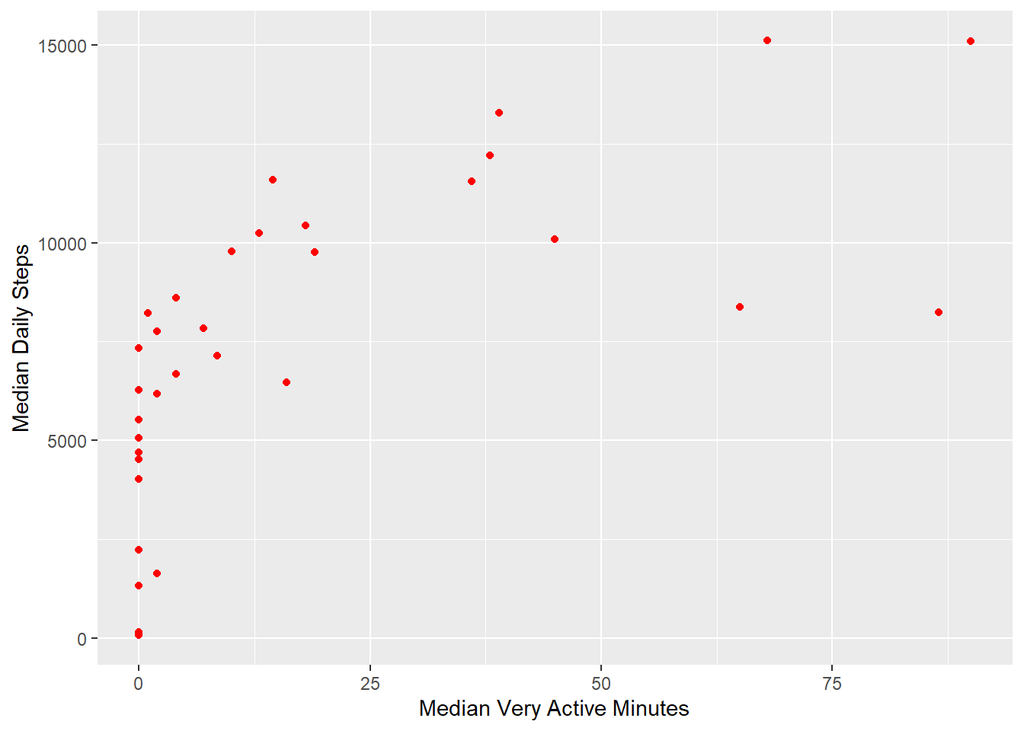

```r
ggplot(data=Daily_Activity_Summary) +
  geom_point(mapping=aes(x=Median_VeryActive, y=Median_Steps), color="red") +
  labs(y="Median Daily Steps", x="Median Very Active Minutes")
```

#### Median Fairly Active Minutes vs. Median Daily Steps

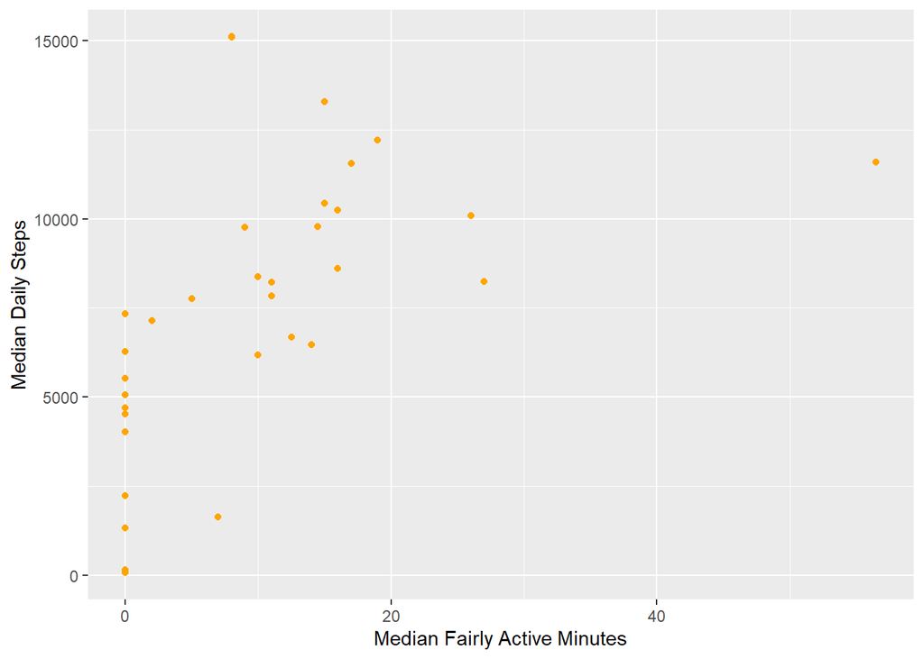

```r
ggplot(data=Daily_Activity_Summary) +
  geom_point(mapping=aes(x=Median_FairlyActive, y=Median_Steps), color="orange") +
  labs(y="Median Daily Steps", x="Median Fairly Active Minutes")
```

#### Median Lightly Active Minutes vs. Median Daily Steps

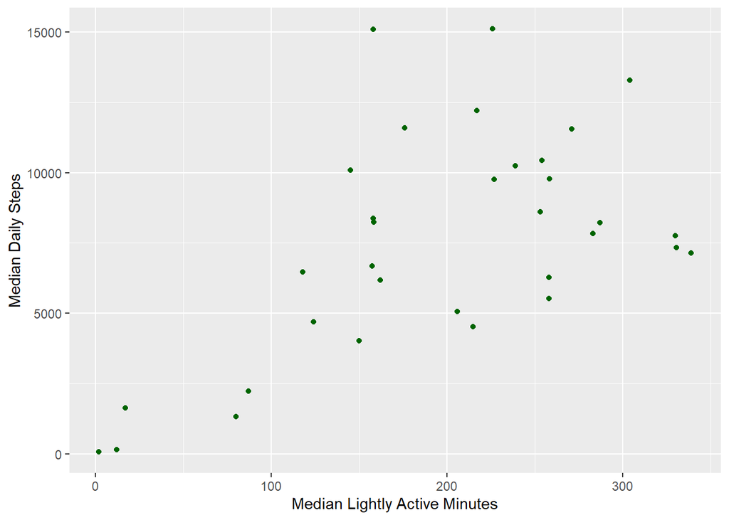

```r
ggplot(data=Daily_Activity_Summary) +
  geom_point(mapping=aes(x=Median_LightlyActive, y=Median_Steps), color="darkgreen") +
  labs(y="Median Daily Steps", x="Median Lightly Active Minutes")
```

## Conclusion

This data helps to refine the picture of our target audience. Based on this sample, most people who use fitness trackers maintain light activity throughout the day but do not exercise strenuously on a typical day. This is the person Bellabeat should have in mind as its target audience.